# Statistics for Bioengineering - Week 8

Bill Cresko

# Week 8: GLMs, Regularization, and Survival Analysis

## Week 8 Topics

- Finish Linear Mixed Models
- Generalized Linear Models (Logistic and Poisson regression)
- Regularization methods (Ridge, Lasso, Elastic Net)
- Splines and LOESS smoothing
- Survival analysis

**Note**

**Readings:** Chapter 29

**HW4 Due next week**

## Packages for This Week

- Install
- Load

```r
# Install new packages (run once)
install.packages(c("lme4", "lmerTest", "emmeans", "broom.mixed",
                    "performance", "patchwork", "survival",
                    "glmnet", "mgcv", "splines"))
```

```r
# Mixed models (replacing nlme with lme4 ecosystem)
library(lme4)         # lmer() — fits linear mixed models
library(lmerTest)     # Adds p-values via Satterthwaite df
library(emmeans)      # Estimated marginal means & contrasts
library(broom.mixed)  # Tidy output for mixed models
library(performance)  # check_model() diagnostics

# Other analysis packages
library(survival)     # Survival analysis (Kaplan-Meier, Cox)
library(glmnet)       # Regularized regression (LASSO, ridge)
library(mgcv)         # Generalized additive models (GAMs)
library(splines)      # Spline basis functions
```

**Datasets for This Week:** `glp1_simple.csv`, `glp1_diet.csv`, `scaffold_degradation_data.csv` — all in the `data/` folder. Additional datasets from packages: `lung` (survival package)

# Finish Linear Mixed Models

## Where We Left Off

Last week we introduced the concept of linear mixed models — models that partition variability into **fixed effects** (treatments you manipulate) and **random effects** (nuisance grouping variables like subjects, batches, or labs).

Today we’ll build intuition for *why* mixed models work by starting with a simple example and progressively adding complexity. We’ll see how moving from a fixed-effects-only model to a random-effects model changes our residuals, our inference, and our understanding of the data.

**Key Insight**

The core idea: subjects (mice, batches, patients) differ from each other in systematic ways. If we ignore this, we either waste degrees of freedom (treating each subject as a fixed effect) or inflate Type I error (ignoring the grouping entirely). Mixed models solve both problems.

## Building Intuition: The GLP-1 Weight Loss Study

We’ll work through two versions of a GLP-1 receptor agonist weight loss experiment:

1. **Simple version:** 6 mice, all on GLP-1, weighed weekly for 10 weeks — introduces random intercepts
2. **Extended version:** 12 mice on GLP-1, half on high-protein diet and half on low-protein diet — introduces random slopes and treatment interactions

For each, we’ll fit three models of increasing sophistication and compare how well they capture the data structure.

# Example 1: Six Mice on GLP-1

## The Experiment

Six mice are placed on a GLP-1 receptor agonist (semaglutide). Each mouse is weighed weekly for 10 weeks. All mice lose weight over time, but they start at different baseline weights and lose weight at slightly different rates.

**The statistical question:** Is there a significant decline in weight over the 10-week treatment period?

**The complication:** Repeated measurements on the same mouse are not independent — each mouse has its own baseline weight, creating within-subject correlation.

## Generate the Dataset

- Output
- Code
- Explanation

```
Dimensions: 66 rows × 3 columns
```

| mouse_id | week | weight |
| --- | --- | --- |
| M1 | 0 | 31.7 |
| M1 | 1 | 33.0 |
| M1 | 2 | 32.2 |
| M1 | 3 | 31.6 |
| M1 | 4 | 31.4 |
| M1 | 5 | 29.7 |
| M1 | 6 | 31.1 |
| M1 | 7 | 29.3 |
| M1 | 8 | 29.2 |
| M1 | 9 | 28.9 |
| M1 | 10 | 26.4 |
| M2 | 0 | 31.5 |

```r
# Read the GLP-1 simple dataset
glp1_simple <- read.csv("data/glp1_simple.csv")
glp1_simple$mouse_id <- factor(glp1_simple$mouse_id)

str(glp1_simple)
head(glp1_simple)
```

## Visualize the Data

- Output
- Code
- Explanation

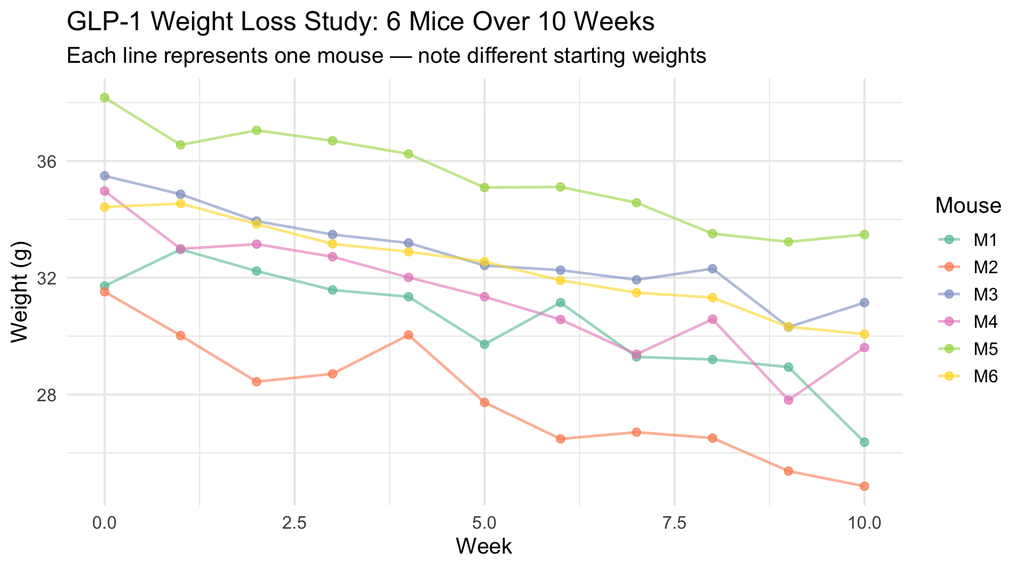

```r
ggplot(glp1_simple, aes(x = week, y = weight,
                         color = mouse_id, group = mouse_id)) +
  geom_line(alpha = 0.6, linewidth = 0.8) +
  geom_point(size = 2, alpha = 0.7) +
  scale_color_brewer(palette = "Set2") +
  labs(title = "GLP-1 Weight Loss Study: 6 Mice Over 10 Weeks",
       x = "Week", y = "Weight (g)", color = "Mouse")
```

## Model 1a: Ignoring the Grouping (Naive lm)

- Output
- Code
- Explanation

```
Call:
lm(formula = weight ~ week, data = glp1_simple)

Residuals:
    Min      1Q  Median      3Q     Max
-4.8146 -1.2801  0.4305  1.0832  4.3145

Coefficients:
            Estimate Std. Error t value Pr(>|t|)
(Intercept)  34.2769     0.5602  61.184  < 2e-16 ***
week         -0.5111     0.0947  -5.398 1.05e-06 ***
---
Signif. codes:  0 '***' 0.001 '**' 0.01 '*' 0.05 '.' 0.1 ' ' 1

Residual standard error: 2.433 on 64 degrees of freedom
Multiple R-squared:  0.3128,    Adjusted R-squared:  0.3021
F-statistic: 29.13 on 1 and 64 DF,  p-value: 1.052e-06
```

```r
# Naive approach: ignore that mice are different
mod_naive <- lm(weight ~ week, data = glp1_simple)
summary(mod_naive)
```

- This model treats all 66 observations as independent — it ignores the mouse grouping entirely
- The slope estimate for `week` captures the average weight loss, but the residual variance is inflated because it includes **both** measurement noise **and** between-mouse variability
- The $R^2$ is lower than it should be because the model can’t explain why some points are consistently high (heavy mice) and others consistently low (light mice)
- The standard error for the slope is inflated, making our test of the time effect less powerful

## Model 1b: Mouse as a Fixed Effect (Parallel Slopes)

- Output
- Code
- Explanation

```
Call:
lm(formula = weight ~ week + mouse_id, data = glp1_simple)

Residuals:
     Min       1Q   Median       3Q      Max
-1.52182 -0.37131  0.04818  0.27460  1.67432

Coefficients:
            Estimate Std. Error t value Pr(>|t|)
(Intercept) 32.96659    0.22840 144.337  < 2e-16 ***
week        -0.51114    0.02477 -20.632  < 2e-16 ***
mouse_idM2  -2.55636    0.27138  -9.420 2.30e-13 ***
mouse_idM3   2.43818    0.27138   8.984 1.21e-12 ***
mouse_idM4   0.96545    0.27138   3.558 0.000746 ***
mouse_idM5   5.01545    0.27138  18.481  < 2e-16 ***
mouse_idM6   1.99909    0.27138   7.366 6.48e-10 ***
---
Signif. codes:  0 '***' 0.001 '**' 0.01 '*' 0.05 '.' 0.1 ' ' 1

Residual standard error: 0.6364 on 59 degrees of freedom
Multiple R-squared:  0.9566,    Adjusted R-squared:  0.9522
F-statistic:   217 on 6 and 59 DF,  p-value: < 2.2e-16
```

```r
# Fixed effect for each mouse — separate intercept per mouse
mod_fixed <- lm(weight ~ week + mouse_id, data = glp1_simple)
summary(mod_fixed)
```

- Adding `mouse_id` as a fixed effect gives each mouse its own intercept — this is the “parallel slopes” model
- The $R^2$ jumps dramatically because we can now explain the between-mouse differences
- The residual standard error drops because we’ve removed the between-mouse variance from the residuals
- **The problem:** this uses 5 extra degrees of freedom (one per additional mouse) just for a nuisance variable. With 6 mice this is manageable, but imagine 100 subjects — you’d burn 99 df on intercepts you don’t care about. And you can’t generalize: these specific intercepts only apply to *these* 6 mice.

## Model 1c: Random Intercept Model (lmer)

- Output
- Code
- Explanation

```
Linear mixed model fit by REML. t-tests use Satterthwaite's method [
lmerModLmerTest]
Formula: weight ~ week + (1 | mouse_id)
   Data: glp1_simple

REML criterion at convergence: 160.3

Scaled residuals:
     Min       1Q   Median       3Q      Max
-2.39422 -0.55019  0.08206  0.43096  2.59607

Random effects:
 Groups   Name        Variance Std.Dev.
 mouse_id (Intercept) 6.4155   2.5329
 Residual             0.4051   0.6364
Number of obs: 66, groups:  mouse_id, 6

Fixed effects:
            Estimate Std. Error       df t value Pr(>|t|)
(Intercept) 34.27689    1.04438  5.14360   32.82 3.56e-07 ***
week        -0.51114    0.02477 59.00000  -20.63  < 2e-16 ***
---
Signif. codes:  0 '***' 0.001 '**' 0.01 '*' 0.05 '.' 0.1 ' ' 1

Correlation of Fixed Effects:
     (Intr)
week -0.119
```

```r
# Random intercept model — mouse as random effect
mod_ri <- lmer(weight ~ week + (1 | mouse_id), data = glp1_simple)
summary(mod_ri)
```

- `(1 | mouse_id)` tells the model that each mouse has its own random baseline, drawn from a normal distribution
- Instead of estimating 6 separate intercepts, we estimate **one variance parameter** ($\sigma^2_{mouse}$) — far more efficient
- The fixed effect of `week` is the population-average slope — it applies to any mouse from this population, not just these 6
- The random effects table shows how much variance is attributable to between-mouse differences vs. within-mouse residual noise
- The **Intraclass Correlation (ICC)** = $\frac{\sigma^2_{mouse}}{\sigma^2_{mouse} + \sigma^2_{resid}}$ tells you what proportion of the total variance is between mice

## Comparing Residuals Across the Three Models

- Output
- Code
- Explanation

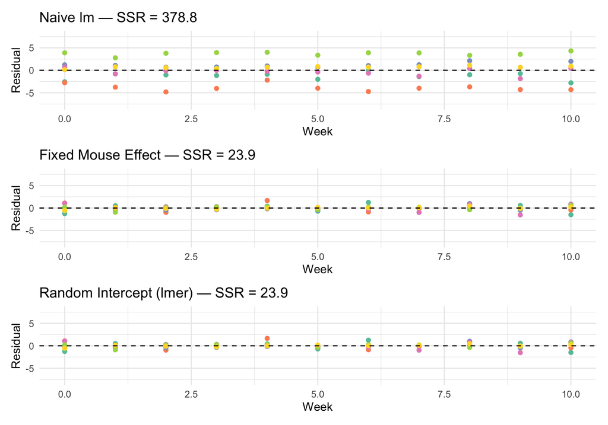

```r
# Compute residuals
glp1_simple$resid_naive <- resid(mod_naive)
glp1_simple$resid_fixed <- resid(mod_fixed)
glp1_simple$resid_lmer  <- resid(mod_ri)

# Sum of squared residuals
cat("SSR (naive):", sum(glp1_simple$resid_naive^2), "\n")
cat("SSR (fixed):", sum(glp1_simple$resid_fixed^2), "\n")
cat("SSR (lmer): ", sum(glp1_simple$resid_lmer^2), "\n")
```

- **Top panel (naive):** Residuals are large and show clear color clustering — heavy mice have positive residuals, light mice have negative. The model is confusing between-mouse variation with treatment effects.
- **Middle panel (fixed):** Adding mouse as a fixed effect removes the clustering. Residuals are now centered around zero for each mouse. SSR drops dramatically.
- **Bottom panel (lmer):** The random intercept model achieves nearly identical residuals to the fixed-effect model, but uses far fewer parameters. The SSR values are very similar because both approaches account for the between-mouse variation.
- The key insight: the random intercept model is just as good at explaining the data, but it’s more **parsimonious** and allows **generalization** to new mice.

## Summary: Example 1 Model Comparison

- Output
- Explanation

| Model | β(week) | SE | p-value | Resid. df | SSR |
| --- | --- | --- | --- | --- | --- |
| Naive lm | -0.51 | 0.09 | 1.05e-06 | 64 | 378.78 |
| Fixed Mouse Effect | -0.51 | 0.02 | < 2e-16 | 59 | 23.90 |
| Random Intercept (lmer) | -0.51 | 0.02 | < 2e-16 | NA | 23.91 |

# Example 2: GLP-1 with Two Diet Groups

## Extending the Design

Now suppose we have 12 mice, all on GLP-1, but randomized into two diet groups: 6 on a **high-protein diet** and 6 on a **low-protein diet**. We measure weight weekly for 10 weeks.

**The statistical question:** Does diet type affect the rate of GLP-1-induced weight loss?

**Why this matters:** Each mouse has its own starting weight (random intercept) and may respond differently to the diet (random slope). We need to account for both sources of individual variation to correctly test the diet effect.

## Generate the Two-Diet Dataset

- Output
- Code
- Explanation

```
Dimensions: 132 rows × 4 columns
```

| mouse_id | diet | week | weight |
| --- | --- | --- | --- |
| M1 | High_Protein | 0 | 33.0 |
| M1 | High_Protein | 1 | 31.4 |
| M1 | High_Protein | 2 | 31.8 |
| M1 | High_Protein | 3 | 33.2 |
| M1 | High_Protein | 4 | 30.9 |
| M1 | High_Protein | 5 | 29.8 |
| M1 | High_Protein | 6 | 30.1 |
| M1 | High_Protein | 7 | 29.9 |
| M1 | High_Protein | 8 | 28.9 |
| M1 | High_Protein | 9 | 28.4 |
| M1 | High_Protein | 10 | 29.0 |
| M2 | High_Protein | 0 | 31.0 |

```r
# Read the GLP-1 diet dataset
glp1_diet <- read.csv("data/glp1_diet.csv")
glp1_diet$mouse_id <- factor(glp1_diet$mouse_id)
glp1_diet$diet <- factor(glp1_diet$diet)

str(glp1_diet)
head(glp1_diet)
```

- 12 mice total: 6 per diet group, each weighed weekly for 10 weeks (132 observations)
- High-protein mice lose ~0.30 g/week; low-protein mice lose ~0.55 g/week
- Individual mice vary around their group mean slope — this is the random slope variability
- Starting weights vary between mice — the random intercept
- Both individual intercept and slope variation need to be modeled to get correct inference about the diet effect

## Visualize the Two-Diet Data

- Output
- Code
- Explanation

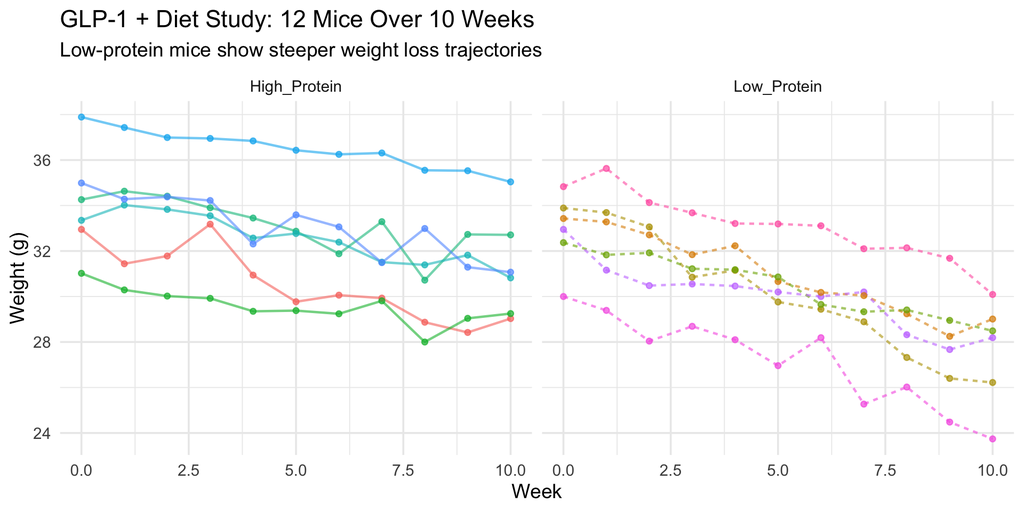

```r
ggplot(glp1_diet, aes(x = week, y = weight, color = mouse_id,
                       group = mouse_id)) +
  geom_line(alpha = 0.6, linewidth = 0.8) +
  geom_point(size = 1.5, alpha = 0.7) +
  facet_wrap(~diet) +
  labs(title = "GLP-1 + Diet Study",
       x = "Week", y = "Weight (g)")
```

- Both groups lose weight, but the **low-protein group** shows steeper decline
- Within each group, mice start at different weights (random intercepts) and the lines aren’t perfectly parallel (random slopes)
- The difference in slopes between groups is the **diet × week interaction** — the key scientific question

## Model 2a: Naive lm (Ignoring Mice)

- Output
- Code
- Explanation

```
Call:
lm(formula = weight ~ week * diet, data = glp1_diet)

Residuals:
    Min      1Q  Median      3Q     Max
-3.9655 -1.4127  0.1092  0.9457  4.3450

Coefficients:
                     Estimate Std. Error t value Pr(>|t|)
(Intercept)          34.07295    0.48521  70.223  < 2e-16 ***
week                 -0.30114    0.08202  -3.672 0.000353 ***
dietLow_Protein      -1.12235    0.68620  -1.636 0.104378
week:dietLow_Protein -0.22959    0.11599  -1.979 0.049913 *
---
Signif. codes:  0 '***' 0.001 '**' 0.01 '*' 0.05 '.' 0.1 ' ' 1

Residual standard error: 2.107 on 128 degrees of freedom
Multiple R-squared:  0.4226,    Adjusted R-squared:  0.409
F-statistic: 31.22 on 3 and 128 DF,  p-value: 3.251e-15
```

```r
mod2_naive <- lm(weight ~ week * diet, data = glp1_diet)
summary(mod2_naive)
```

## Model 2b: Parallel Slopes with Mouse as Fixed Effect

- Output
- Code
- Explanation

```
Call:
lm(formula = weight ~ week * diet + mouse_id, data = glp1_diet)

Residuals:
     Min       1Q   Median       3Q      Max
-1.54477 -0.38842 -0.04352  0.41761  1.99864

Coefficients: (1 not defined because of singularities)
                     Estimate Std. Error t value Pr(>|t|)
(Intercept)          32.08477    0.23933 134.062  < 2e-16 ***
week                 -0.30114    0.02596 -11.601  < 2e-16 ***
dietLow_Protein       3.64068    0.33846  10.757  < 2e-16 ***
mouse_idM10          -2.08364    0.28436  -7.327 3.17e-11 ***
mouse_idM11          -3.01091    0.28436 -10.588  < 2e-16 ***
mouse_idM12          -2.59818    0.28436  -9.137 2.20e-15 ***
mouse_idM2           -1.00455    0.28436  -3.533 0.000588 ***
mouse_idM3            2.58909    0.28436   9.105 2.62e-15 ***
mouse_idM4            1.96818    0.28436   6.921 2.49e-10 ***
mouse_idM5            5.89455    0.28436  20.729  < 2e-16 ***
mouse_idM6            2.48182    0.28436   8.728 2.00e-14 ***
mouse_idM7           -3.05545    0.28436 -10.745  < 2e-16 ***
mouse_idM8           -5.90091    0.28436 -20.751  < 2e-16 ***
mouse_idM9                 NA         NA      NA       NA
week:dietLow_Protein -0.22959    0.03671  -6.254 6.63e-09 ***
---
Signif. codes:  0 '***' 0.001 '**' 0.01 '*' 0.05 '.' 0.1 ' ' 1

Residual standard error: 0.6669 on 118 degrees of freedom
Multiple R-squared:  0.9467,    Adjusted R-squared:  0.9408
F-statistic: 161.1 on 13 and 118 DF,  p-value: < 2.2e-16
```

```r
# Fixed intercept per mouse + diet interaction with week
mod2_fixed <- lm(weight ~ week * diet + mouse_id, data = glp1_diet)
summary(mod2_fixed)
```

- Each mouse gets its own intercept, accounting for different starting weights
- The `week:diet` interaction still tests slope differences between diets
- **Problem 1:** We use 11 extra df for mouse intercepts — a nuisance variable
- **Problem 2:** This model assumes all mice within a diet group have the *same* slope. If mice actually differ in their response rate, this model underestimates uncertainty
- **Problem 3:** We can’t generalize — these intercepts apply only to these 12 mice

## Model 2c: Random Intercept and Random Slope

- Output
- Code
- Explanation

```
Linear mixed model fit by REML. t-tests use Satterthwaite's method [
lmerModLmerTest]
Formula: weight ~ week * diet + (1 + week | mouse_id)
   Data: glp1_diet

REML criterion at convergence: 305.7

Scaled residuals:
     Min       1Q   Median       3Q      Max
-2.89854 -0.52726 -0.02882  0.61919  3.12789

Random effects:
 Groups   Name        Variance Std.Dev. Corr
 mouse_id (Intercept) 4.46148  2.1122
          week        0.01367  0.1169   -0.06
 Residual             0.31735  0.5633
Number of obs: 132, groups:  mouse_id, 12

Fixed effects:
                     Estimate Std. Error       df t value Pr(>|t|)
(Intercept)          34.07295    0.87201 10.00327  39.074 2.86e-12 ***
week                 -0.30114    0.05252  9.99975  -5.734 0.000189 ***
dietLow_Protein      -1.12235    1.23321 10.00327  -0.910 0.384175
week:dietLow_Protein -0.22959    0.07428  9.99975  -3.091 0.011425 *
---
Signif. codes:  0 '***' 0.001 '**' 0.01 '*' 0.05 '.' 0.1 ' ' 1

Correlation of Fixed Effects:
            (Intr) week   dtLw_P
week        -0.105
dietLw_Prtn -0.707  0.074
wk:dtLw_Prt  0.074 -0.707 -0.105
```

```r
# Random intercept only
mod2_ri  <- lmer(weight ~ week * diet + (1 | mouse_id),
                  data = glp1_diet)

# Random intercept AND random slope for week
mod2_ris <- lmer(weight ~ week * diet + (1 + week | mouse_id),
                  data = glp1_diet)
summary(mod2_ris)
```

- `(1 + week | mouse_id)` gives each mouse its own intercept *and* its own rate of weight change
- The model estimates the variance of the random intercepts, the variance of the random slopes, and their correlation
- A negative intercept-slope correlation would mean heavier mice lose weight faster — this is a biologically interpretable parameter
- The fixed effect `week:dietLow_Protein` tests the population-level diet difference in slopes, properly accounting for individual variation
- This is the **most appropriate model** because it respects the full data structure

## Comparing Residuals: Two-Diet Models

- Output
- Explanation

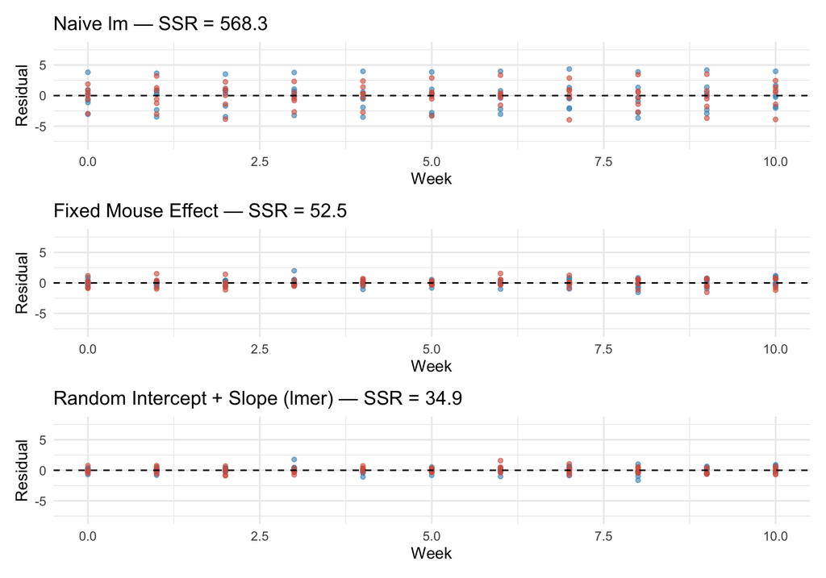

- **Naive model:** Residuals are large because between-mouse variation is treated as noise
- **Fixed mouse model:** Residuals shrink but still show some patterning because the parallel-slopes assumption forces all mice within a group to share one slope
- **Random slope model (lmer):** The smallest residuals — each mouse gets its own trajectory, and the model properly separates individual variation from the diet effect
- The progressive SSR reduction shows that each model captures more of the systematic variation in the data

## Summary: Example 2 Model Comparison

- Output
- Explanation

| Model | β(week×diet) | SE | p-value | SSR |
| --- | --- | --- | --- | --- |
| Naive lm | -0.23 | 0.12 | 0.0499 | 568.27 |
| Fixed Mouse | -0.23 | 0.04 | 6.63e-09 | 52.48 |
| Random Int+Slope (lmer) | -0.23 | 0.07 | 0.0114 | 34.87 |

## The Big Picture: Why Mixed Models Matter

**Three Models, Three Philosophies**

1. **Naive `lm()`**: Pretend all observations are independent. Fast, simple, wrong. Inflated Type I error.
2. **Fixed effects `lm()` + subject**: Give each subject its own intercept. Correct residuals, but wastes df and can’t generalize.
3. **Mixed model `lmer()`**: Treat subjects as random draws from a population. Efficient, generalizable, and honest about uncertainty.

The mixed model is the right tool whenever your data has a grouping structure — which in bioengineering, it almost always does.

## Post-Hoc: Comparing Diet Slopes with emmeans

- Output
- Code
- Explanation

```
=== Estimated Slopes by Diet ===
```

```
 diet         week.trend     SE df lower.CL upper.CL
 High_Protein     -0.301 0.0525 10   -0.418   -0.184
 Low_Protein      -0.531 0.0525 10   -0.648   -0.414

Degrees-of-freedom method: kenward-roger
Confidence level used: 0.95
```

```
=== Pairwise Comparison of Slopes ===
```

```
 contrast                   estimate     SE df t.ratio p.value
 High_Protein - Low_Protein     0.23 0.0743 10   3.091  0.0114

Degrees-of-freedom method: kenward-roger
```

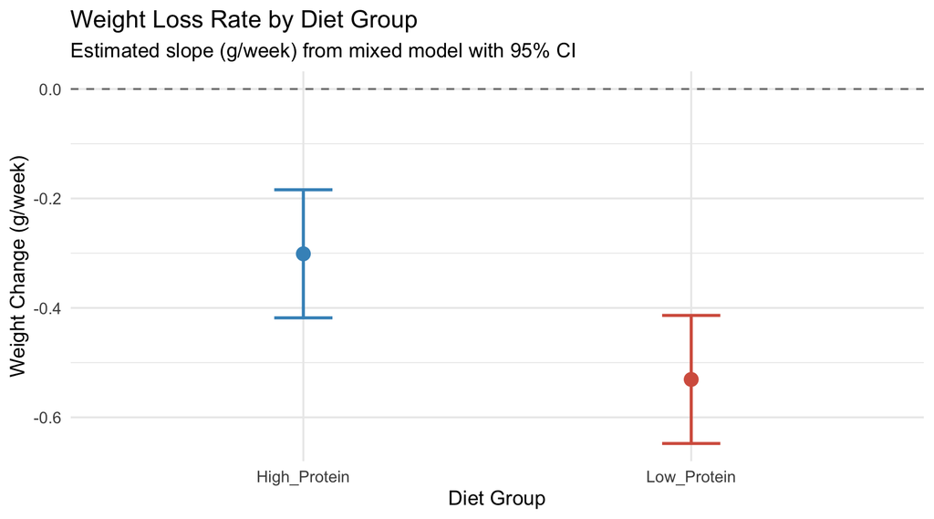

```r
library(emmeans)

# Compare the weekly weight-loss slopes between diet groups
diet_trends <- emtrends(mod2_ris, pairwise ~ diet, var = "week")

# View slopes
diet_trends$emtrends

# Pairwise comparison
diet_trends$contrasts
```

- `emtrends()` estimates the slope (rate of weight change per week) for each diet group from the mixed model
- The pairwise contrast tests whether the slopes differ significantly between high-protein and low-protein groups
- Both slopes are negative (weight loss), but low-protein mice have a steeper decline
- The confidence intervals come from the mixed model, so they properly account for within-mouse correlation
- This is the mixed-model equivalent of testing the `week × diet` interaction, but expressed as a comparison of estimated rates

## Choosing the Right Statistical Model

When selecting a model, the nature of your response variable guides the choice:

[figure not shown]

The remainder of this lecture introduces the methods on the right side of this flowchart: GLMs (logistic, Poisson), regularization, splines, and survival analysis.

# Applying lme4 to a Complex Bioengineering Design

## From Simple to Complex

The mouse GLP-1 examples had one random grouping factor (mouse). Real bioengineering experiments often have **multiple** sources of random variation:

- **Batches** of manufactured scaffolds
- **Labs** where experiments are conducted
- **Technicians** nested within labs

We’ll now work through a realistic scaffold degradation experiment that demonstrates nested and crossed random effects, model comparison, and the full lme4/lmerTest workflow.

## Fixed vs. Random Effects — A Quick Review

**Fixed Effects**

- Specific, repeatable levels
- You care about *these* levels
- Treatment conditions, drug doses, scaffold coatings
- Estimated as regression coefficients (β)

**Random Effects**

- Levels are a *sample* from a larger population
- You care about the *variability*, not specific levels
- Batches, labs, technicians, patients
- Estimated as variance components (σ²)

**Rule of Thumb**

Ask: “If I repeated this experiment, would I use *these exact same* levels?” If yes → fixed. If you’d get a new random sample → random.

## The Mixed Model Equation

$$\mathbf{y} = \mathbf{X}\boldsymbol{\beta} + \mathbf{Z}\mathbf{u} + \boldsymbol{\varepsilon}$$

Where:

- $\mathbf{y}$ — vector of observed responses (degradation rates)
- $\mathbf{X}\boldsymbol{\beta}$ — fixed effects (treatment, temperature, their interaction)
- $\mathbf{Z}\mathbf{u}$ — random effects, where $\mathbf{u} \sim N(\mathbf{0}, \mathbf{G})$
- $\boldsymbol{\varepsilon}$ — residual error, where $\boldsymbol{\varepsilon} \sim N(\mathbf{0}, \mathbf{R})$
- Random effects **shrink** estimates toward the grand mean — partial pooling

# The Scaffold Degradation Dataset

## Study Design

**Research Question:** How do scaffold coating type and incubation temperature affect scaffold degradation rate (percent mass loss over 28 days)?

| Factor | Type | Levels |
| --- | --- | --- |
| `treatment` | Fixed | A_collagen, B_fibronectin, C_uncoated |
| `temperature` | Fixed | 37°C, 42°C |
| `batch` | Random | 6 manufacturing batches (crossed with lab) |
| `lab` | Random | 4 testing laboratories |
| `technician` | Random (nested in lab) | 10 technicians (2–3 per lab) |

**Replication:** 3 scaffolds per treatment × temperature × technician × batch = **1,080 observations**

## Load and Inspect the Data

- Output
- Code
- Explanation

```
'data.frame':   1080 obs. of  7 variables:
 $ scaffold_id: chr  "S_0001" "S_0002" "S_0003" "S_0004" ...
 $ treatment  : Factor w/ 3 levels "A_collagen","B_fibronectin",..: 1 1 1 1 1 1 2 2 2 2 ...
 $ temperature: Factor w/ 2 levels "37C","42C": 1 1 1 2 2 2 1 1 1 2 ...
 $ batch      : Factor w/ 6 levels "Batch_1","Batch_2",..: 1 1 1 1 1 1 1 1 1 1 ...
 $ lab        : Factor w/ 4 levels "Lab_1","Lab_2",..: 1 1 1 1 1 1 1 1 1 1 ...
 $ technician : Factor w/ 10 levels "Tech_1A","Tech_1B",..: 1 1 1 1 1 1 1 1 1 1 ...
 $ degradation: num  24 24.8 17.9 31.7 28.4 24.9 26.6 32.8 26.8 30.5 ...
```

```r
# Read the CSV
scaffold_data <- read.csv("data/scaffold_degradation_data.csv")

# Convert grouping variables to factors
scaffold_data <- scaffold_data %>%
  mutate(
    treatment   = factor(treatment),
    temperature = factor(temperature),
    batch       = factor(batch),
    lab         = factor(lab),
    technician  = factor(technician)
  )

str(scaffold_data)
```

- All grouping variables must be converted to **factors** for `lmer()` to recognize them as categorical
- `treatment` and `temperature` are fixed factors with specific, meaningful levels
- `batch`, `lab`, and `technician` are random grouping factors
- The `str()` output confirms 1,080 observations and proper factor encoding

## Summary Statistics by Treatment and Temperature

- Output
- Code
- Explanation

| treatment | temperature | n | mean | sd |
| --- | --- | --- | --- | --- |
| A_collagen | 37C | 180 | 25.5 | 4.4 |
| A_collagen | 42C | 180 | 30.5 | 4.3 |
| B_fibronectin | 37C | 180 | 29.1 | 4.4 |
| B_fibronectin | 42C | 180 | 35.2 | 4.2 |
| C_uncoated | 37C | 180 | 34.4 | 4.6 |
| C_uncoated | 42C | 180 | 44.5 | 4.3 |

```r
scaffold_data %>%
  group_by(treatment, temperature) %>%
  summarise(
    n    = n(),
    mean = round(mean(degradation), 1),
    sd   = round(sd(degradation), 1),
    .groups = "drop"
  ) %>%
  kable()
```

- Uncoated scaffolds at 42°C show the highest degradation — consistent with expectations
- Collagen-coated scaffolds at 37°C show the lowest degradation
- The standard deviations include **both** residual and random effect variability
- We need mixed models to separate these variance sources

## Visualize the Data

- Output
- Code
- Explanation

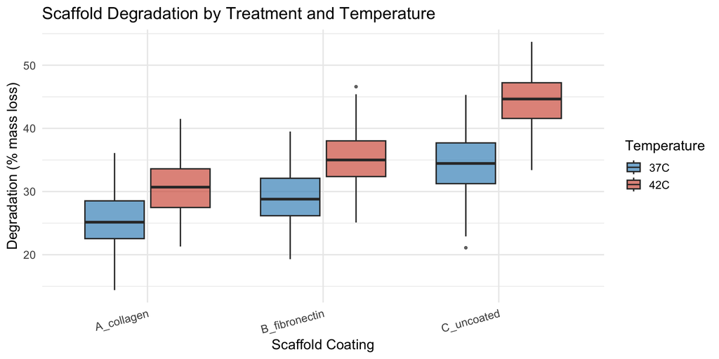

```r
ggplot(scaffold_data, aes(x = treatment, y = degradation, fill = temperature)) +
  geom_boxplot(alpha = 0.7, outlier.size = 1) +
  scale_fill_manual(values = c("37C" = "#4393c3", "42C" = "#d6604d")) +
  labs(
    x = "Scaffold Coating",
    y = "Degradation (% mass loss)",
    fill = "Temperature",
    title = "Scaffold Degradation by Treatment and Temperature"
  ) +
  theme(axis.text.x = element_text(angle = 15, hjust = 1))
```

- The boxplots show a clear **treatment × temperature interaction** pattern
- Uncoated scaffolds show a much larger temperature effect than collagen-coated
- Notice the spread within each group — some of this is batch-to-batch and lab-to-lab variability
- The mixed model will help us separate true treatment effects from random variation

## Variability Across Random Groups

- Output
- Code
- Explanation

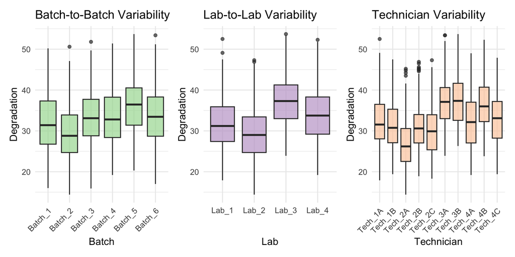

```r
p1 <- ggplot(scaffold_data, aes(x = batch, y = degradation)) +
  geom_boxplot(fill = "#a6dba0", alpha = 0.7) +
  labs(x = "Batch", y = "Degradation", title = "Batch-to-Batch Variability") +
  theme(axis.text.x = element_text(angle = 45, hjust = 1))

p2 <- ggplot(scaffold_data, aes(x = lab, y = degradation)) +
  geom_boxplot(fill = "#c2a5cf", alpha = 0.7) +
  labs(x = "Lab", y = "Degradation", title = "Lab-to-Lab Variability")

p3 <- ggplot(scaffold_data, aes(x = technician, y = degradation)) +
  geom_boxplot(fill = "#fdcdac", alpha = 0.7) +
  labs(x = "Technician", y = "Degradation", title = "Technician Variability") +
  theme(axis.text.x = element_text(angle = 45, hjust = 1))

p1 + p2 + p3  # patchwork combines plots
```

- **Batch:** systematic shifts in degradation across manufacturing runs
- **Lab:** some labs produce consistently higher or lower readings
- **Technician:** individual variation within labs
- These are exactly the sources of non-independence that mixed models capture
- Using `lm()` would lump all this variability into the residual, inflating the error term and potentially missing real treatment effects

# Model 1: Random Intercept Model

## Random Intercept — Accounting for Batch Variability

- Output
- Code
- Explanation

```
Linear mixed model fit by REML. t-tests use Satterthwaite's method [
lmerModLmerTest]
Formula: degradation ~ treatment * temperature + (1 | batch)
   Data: scaffold_data

REML criterion at convergence: 5992.3

Scaled residuals:
     Min       1Q   Median       3Q      Max
-2.70491 -0.66678 -0.08796  0.72154  2.67982

Random effects:
 Groups   Name        Variance Std.Dev.
 batch    (Intercept)  5.186   2.277
 Residual             14.778   3.844
Number of obs: 1080, groups:  batch, 6

Fixed effects:
                                       Estimate Std. Error        df t value
(Intercept)                             25.4661     0.9728    5.8094  26.177
treatmentB_fibronectin                   3.6750     0.4052 1069.0000   9.069
treatmentC_uncoated                      8.9172     0.4052 1069.0000  22.006
temperature42C                           5.0350     0.4052 1069.0000  12.426
treatmentB_fibronectin:temperature42C    1.0400     0.5731 1069.0000   1.815
treatmentC_uncoated:temperature42C       5.0994     0.5731 1069.0000   8.899
                                      Pr(>|t|)
(Intercept)                           2.98e-07 ***
treatmentB_fibronectin                 < 2e-16 ***
treatmentC_uncoated                    < 2e-16 ***
temperature42C                         < 2e-16 ***
treatmentB_fibronectin:temperature42C   0.0698 .
treatmentC_uncoated:temperature42C     < 2e-16 ***
---
Signif. codes:  0 '***' 0.001 '**' 0.01 '*' 0.05 '.' 0.1 ' ' 1

Correlation of Fixed Effects:
            (Intr) trtmB_ trtmC_ tmp42C tB_:42
trtmntB_fbr -0.208
trtmntC_nct -0.208  0.500
tempertr42C -0.208  0.500  0.500
trtmnB_:42C  0.147 -0.707 -0.354 -0.707
trtmnC_:42C  0.147 -0.354 -0.707 -0.707  0.500
```

```r
mod_ri <- lmer(degradation ~ treatment * temperature + (1 | batch),
               data = scaffold_data)
summary(mod_ri)
```

- `degradation ~ treatment * temperature` — the fixed effects: main effects + interaction
- `(1 | batch)` — a **random intercept** for batch
- Each batch gets its own baseline offset from the grand mean
- These offsets are assumed to follow $N(0, \sigma^2_{batch})$
- The `Random effects` table shows the estimated $\sigma_{batch}$ and $\sigma_{residual}$
- **Intraclass Correlation (ICC):** $\frac{\sigma^2_{batch}}{\sigma^2_{batch} + \sigma^2_{resid}}$ tells you what proportion of total variance is attributable to batch

## Interpreting the Random Effects Table

- Output
- Code
- Explanation

```
 Groups   Name        Std.Dev.
 batch    (Intercept) 2.2772
 Residual             3.8442
```

```r
VarCorr(mod_ri)
```

- `VarCorr()` extracts the variance component estimates
- **Batch variance** ($\sigma^2_{batch}$): how much the average degradation shifts from batch to batch
- **Residual variance** ($\sigma^2_{resid}$): leftover variability after accounting for fixed effects and batch
- If batch variance is large relative to residual, batch is an important source of non-independence
- These are REML (Restricted Maximum Likelihood) estimates — the default and usually preferred

## ANOVA Table for Fixed Effects

- Output
- Code
- Explanation

```
Type III Analysis of Variance Table with Satterthwaite's method
                      Sum Sq Mean Sq NumDF DenDF F value    Pr(>F)
treatment              24236 12118.2     2  1069  820.02 < 2.2e-16 ***
temperature            13540 13539.8     1  1069  916.22 < 2.2e-16 ***
treatment:temperature   1307   653.5     2  1069   44.22 < 2.2e-16 ***
---
Signif. codes:  0 '***' 0.001 '**' 0.01 '*' 0.05 '.' 0.1 ' ' 1
```

```r
anova(mod_ri, type = 3)
```

- `lmerTest` automatically provides F-tests with **Satterthwaite** degrees of freedom
- Satterthwaite approximation adjusts the denominator df to account for the random effects structure
- The `treatment:temperature` row tests the interaction — whether the temperature effect differs across coating types
- Type 3 SS tests each effect adjusted for all others, appropriate when you have an interaction
- Compare these p-values to what you would get from a standard `lm()` — the mixed model often has different (usually more conservative) conclusions

# Model 2: Random Intercept and Random Slope

## Does the Temperature Effect Vary Across Batches?

- Output
- Code
- Explanation

```
Linear mixed model fit by REML. t-tests use Satterthwaite's method [
lmerModLmerTest]
Formula: degradation ~ treatment * temperature + (1 + temperature | batch)
   Data: scaffold_data

REML criterion at convergence: 5992.2

Scaled residuals:
     Min       1Q   Median       3Q      Max
-2.70243 -0.67331 -0.07919  0.71880  2.68251

Random effects:
 Groups   Name           Variance  Std.Dev. Corr
 batch    (Intercept)     5.022580 2.24111
          temperature42C  0.005217 0.07223  1.00
 Residual                14.776775 3.84406
Number of obs: 1080, groups:  batch, 6

Fixed effects:
                                       Estimate Std. Error        df t value
(Intercept)                             25.4661     0.9587    5.6568  26.562
treatmentB_fibronectin                   3.6750     0.4052 1069.0000   9.070
treatmentC_uncoated                      8.9172     0.4052 1069.0000  22.007
temperature42C                           5.0350     0.4063  612.7304  12.393
treatmentB_fibronectin:temperature42C    1.0400     0.5730 1069.0000   1.815
treatmentC_uncoated:temperature42C       5.0994     0.5730 1069.0000   8.899
                                      Pr(>|t|)
(Intercept)                           3.71e-07 ***
treatmentB_fibronectin                 < 2e-16 ***
treatmentC_uncoated                    < 2e-16 ***
temperature42C                         < 2e-16 ***
treatmentB_fibronectin:temperature42C   0.0698 .
treatmentC_uncoated:temperature42C     < 2e-16 ***
---
Signif. codes:  0 '***' 0.001 '**' 0.01 '*' 0.05 '.' 0.1 ' ' 1

Correlation of Fixed Effects:
            (Intr) trtmB_ trtmC_ tmp42C tB_:42
trtmntB_fbr -0.211
trtmntC_nct -0.211  0.500
tempertr42C -0.141  0.499  0.499
trtmnB_:42C  0.149 -0.707 -0.354 -0.705
trtmnC_:42C  0.149 -0.354 -0.707 -0.705  0.500
optimizer (nloptwrap) convergence code: 0 (OK)
boundary (singular) fit: see help('isSingular')
```

```r
mod_ris <- lmer(degradation ~ treatment * temperature +
                  (1 + temperature | batch),
                data = scaffold_data)
summary(mod_ris)
```

- `(1 + temperature | batch)` — **random intercept AND random slope** for temperature, grouped by batch
- Each batch now gets its own baseline *and* its own temperature effect
- The model estimates three variance parameters: $\sigma^2_{intercept}$, $\sigma^2_{slope}$, and the **correlation** between them
- A positive correlation would mean batches with higher baseline degradation also show a bigger temperature effect
- This is a more complex model — check whether it improves fit before adopting it

## Removing the Intercept-Slope Correlation

- Output
- Code
- Explanation

```
 Groups   Name           Std.Dev.   Corr
 batch    (Intercept)    2.27716692
 batch.1  temperature37C 0.00049403
          temperature42C 0.00049912 1.000
 Residual                3.84420210
```

```r
# Use || instead of | to remove the correlation
mod_ris_nocorr <- lmer(degradation ~ treatment * temperature +
                         (1 + temperature || batch),
                       data = scaffold_data)
VarCorr(mod_ris_nocorr)
```

- `||` (double pipe) forces the random intercept and slope to be **uncorrelated**
- This estimates a diagonal covariance matrix instead of a full matrix
- Use this when you have few groups and the correlation is poorly estimated, or when the correlated model fails to converge
- Compare AIC/BIC of the correlated vs. uncorrelated models to decide

## Comparing Random Intercept vs. Random Slope Models

- Output
- Code
- Explanation

```
Data: scaffold_data
Models:
mod_ri: degradation ~ treatment * temperature + (1 | batch)
mod_ris: degradation ~ treatment * temperature + (1 + temperature | batch)
        npar    AIC    BIC  logLik -2*log(L)  Chisq Df Pr(>Chisq)
mod_ri     8 6008.3 6048.1 -2996.1    5992.3
mod_ris   10 6012.2 6062.0 -2996.1    5992.2 0.0792  2     0.9612
```

```r
anova(mod_ri, mod_ris, refit = FALSE)
```

- `anova()` on two `lmer` models performs a **likelihood ratio test** comparing nested models
- `refit = FALSE` keeps the REML estimates — use this when comparing models that differ only in random effects
- A significant p-value means the random slope significantly improves fit — the temperature effect truly varies across batches
- Also compare **AIC** and **BIC**: lower values = better model (BIC penalizes complexity more)
- If the random slope model fails to converge or has a near-zero slope variance, stick with the simpler random intercept model

# Model 3: Nested Random Effects

## Technicians Nested Within Labs

- Output
- Code
- Explanation

```
Linear mixed model fit by REML. t-tests use Satterthwaite's method [
lmerModLmerTest]
Formula:
degradation ~ treatment * temperature + (1 | lab) + (1 | lab:technician)
   Data: scaffold_data

REML criterion at convergence: 5460.3

Scaled residuals:
    Min      1Q  Median      3Q     Max
-3.5210 -0.6397  0.0248  0.6741  3.5365

Random effects:
 Groups         Name        Variance Std.Dev.
 lab:technician (Intercept) 3.571    1.890
 lab            (Intercept) 9.754    3.123
 Residual                   8.844    2.974
Number of obs: 1080, groups:  lab:technician, 10; lab, 4

Fixed effects:
                                       Estimate Std. Error        df t value
(Intercept)                             25.7153     1.6905    3.0532  15.212
treatmentB_fibronectin                   3.6750     0.3135 1065.0001  11.723
treatmentC_uncoated                      8.9172     0.3135 1065.0001  28.446
temperature42C                           5.0350     0.3135 1065.0001  16.062
treatmentB_fibronectin:temperature42C    1.0400     0.4433 1065.0001   2.346
treatmentC_uncoated:temperature42C       5.0994     0.4433 1065.0001  11.503
                                      Pr(>|t|)
(Intercept)                            0.00056 ***
treatmentB_fibronectin                 < 2e-16 ***
treatmentC_uncoated                    < 2e-16 ***
temperature42C                         < 2e-16 ***
treatmentB_fibronectin:temperature42C  0.01916 *
treatmentC_uncoated:temperature42C     < 2e-16 ***
---
Signif. codes:  0 '***' 0.001 '**' 0.01 '*' 0.05 '.' 0.1 ' ' 1

Correlation of Fixed Effects:
            (Intr) trtmB_ trtmC_ tmp42C tB_:42
trtmntB_fbr -0.093
trtmntC_nct -0.093  0.500
tempertr42C -0.093  0.500  0.500
trtmnB_:42C  0.066 -0.707 -0.354 -0.707
trtmnC_:42C  0.066 -0.354 -0.707 -0.707  0.500
```

```r
mod_nested <- lmer(degradation ~ treatment * temperature +
                     (1 | lab) + (1 | lab:technician),
                   data = scaffold_data)
summary(mod_nested)
```

- `(1 | lab)` — random intercept for lab
- `(1 | lab:technician)` — random intercept for technician **nested within** lab
- The `lab:technician` interaction creates unique IDs: “Lab_1:Tech_1A” is distinct from “Lab_2:Tech_2A”
- This is essential when technician IDs repeat across labs (Tech_1A in Lab 1 ≠ Tech_1A in Lab 2)
- The random effects table will show three variance components: lab, technician-within-lab, and residual

## Understanding Nesting Syntax

In `lme4`, nesting is specified via two terms:

$$\texttt{(1 | lab) + (1 | lab:technician)}$$

**Common Mistake**

If technician IDs are unique across labs (e.g., “Tech_1A”, “Tech_2A”), then `(1 | lab) + (1 | technician)` works. But if technician is just coded as “1”, “2”, “3” in each lab, you **must** use `lab:technician` or the model treats all “Technician 1” entries as the same person!

**Always check your data coding.** A safe practice is to always use `lab:technician` for nested designs, regardless of how the variable is coded.

# Model 4: Crossed Random Effects

## Batches Crossed with Labs

- Output
- Code
- Explanation

```
Linear mixed model fit by REML. t-tests use Satterthwaite's method [
lmerModLmerTest]
Formula: degradation ~ treatment * temperature + (1 | batch) + (1 | lab)
   Data: scaffold_data

REML criterion at convergence: 5149.4

Scaled residuals:
     Min       1Q   Median       3Q      Max
-2.99925 -0.66866 -0.00037  0.66410  2.91593

Random effects:
 Groups   Name        Variance Std.Dev.
 batch    (Intercept)  5.231   2.287
 lab      (Intercept) 11.360   3.370
 Residual              6.603   2.570
Number of obs: 1080, groups:  batch, 6; lab, 4

Fixed effects:
                                       Estimate Std. Error        df t value
(Intercept)                             25.7535     1.9362    4.9219  13.301
treatmentB_fibronectin                   3.6750     0.2709 1065.9995  13.568
treatmentC_uncoated                      8.9172     0.2709 1065.9995  32.921
temperature42C                           5.0350     0.2709 1065.9995  18.589
treatmentB_fibronectin:temperature42C    1.0400     0.3831 1065.9995   2.715
treatmentC_uncoated:temperature42C       5.0994     0.3831 1065.9995  13.312
                                      Pr(>|t|)
(Intercept)                           4.79e-05 ***
treatmentB_fibronectin                 < 2e-16 ***
treatmentC_uncoated                    < 2e-16 ***
temperature42C                         < 2e-16 ***
treatmentB_fibronectin:temperature42C  0.00674 **
treatmentC_uncoated:temperature42C     < 2e-16 ***
---
Signif. codes:  0 '***' 0.001 '**' 0.01 '*' 0.05 '.' 0.1 ' ' 1

Correlation of Fixed Effects:
            (Intr) trtmB_ trtmC_ tmp42C tB_:42
trtmntB_fbr -0.070
trtmntC_nct -0.070  0.500
tempertr42C -0.070  0.500  0.500
trtmnB_:42C  0.049 -0.707 -0.354 -0.707
trtmnC_:42C  0.049 -0.354 -0.707 -0.707  0.500
```

```r
mod_crossed <- lmer(degradation ~ treatment * temperature +
                      (1 | batch) + (1 | lab),
                    data = scaffold_data)
summary(mod_crossed)
```

- `(1 | batch) + (1 | lab)` — two **separate** random intercepts with no nesting relationship
- This means every batch was tested in every lab (fully crossed)
- `lme4` handles crossed random effects natively and efficiently
- The model estimates independent variance components for batch and lab
- **Crossed vs. Nested:** if every combination of batch × lab exists in your data, the design is crossed. If batches only appear within specific labs, it’s nested.

## Crossed vs. Nested — Visualizing the Difference

**Crossed Design**

|  | Lab 1 | Lab 2 | Lab 3 |
| --- | --- | --- | --- |
| Batch 1 | ✓ | ✓ | ✓ |
| Batch 2 | ✓ | ✓ | ✓ |
| Batch 3 | ✓ | ✓ | ✓ |

Every batch appears in every lab.

`(1 | batch) + (1 | lab)`

**Nested Design**

|  | Lab 1 | Lab 2 | Lab 3 |
| --- | --- | --- | --- |
| Tech A | ✓ |  |  |
| Tech B | ✓ |  |  |
| Tech C |  | ✓ |  |
| Tech D |  | ✓ |  |
| Tech E |  |  | ✓ |

Each technician belongs to exactly one lab.

`(1 | lab) + (1 | lab:technician)`

# Model 5: Full Mixed Model

## Combining Crossed and Nested Random Effects

- Output
- Code
- Explanation

```
Linear mixed model fit by REML. t-tests use Satterthwaite's method [
lmerModLmerTest]
Formula: degradation ~ treatment * temperature + (1 | batch) + (1 | lab) +
    (1 | lab:technician)
   Data: scaffold_data

REML criterion at convergence: 4746.8

Scaled residuals:
    Min      1Q  Median      3Q     Max
-3.2687 -0.6112 -0.0383  0.6630  3.4546

Random effects:
 Groups         Name        Variance Std.Dev.
 lab:technician (Intercept) 3.612    1.900
 batch          (Intercept) 5.243    2.290
 lab            (Intercept) 9.748    3.122
 Residual                   4.413    2.101
Number of obs: 1080, groups:  lab:technician, 10; batch, 6; lab, 4

Fixed effects:
                                       Estimate Std. Error        df t value
(Intercept)                             25.7152     1.9261    4.8723  13.351
treatmentB_fibronectin                   3.6750     0.2214 1059.9994  16.596
treatmentC_uncoated                      8.9172     0.2214 1059.9994  40.269
temperature42C                           5.0350     0.2214 1059.9994  22.737
treatmentB_fibronectin:temperature42C    1.0400     0.3132 1059.9994   3.321
treatmentC_uncoated:temperature42C       5.0994     0.3132 1059.9994  16.284
                                      Pr(>|t|)
(Intercept)                           5.05e-05 ***
treatmentB_fibronectin                 < 2e-16 ***
treatmentC_uncoated                    < 2e-16 ***
temperature42C                         < 2e-16 ***
treatmentB_fibronectin:temperature42C 0.000928 ***
treatmentC_uncoated:temperature42C     < 2e-16 ***
---
Signif. codes:  0 '***' 0.001 '**' 0.01 '*' 0.05 '.' 0.1 ' ' 1

Correlation of Fixed Effects:
            (Intr) trtmB_ trtmC_ tmp42C tB_:42
trtmntB_fbr -0.057
trtmntC_nct -0.057  0.500
tempertr42C -0.057  0.500  0.500
trtmnB_:42C  0.041 -0.707 -0.354 -0.707
trtmnC_:42C  0.041 -0.354 -0.707 -0.707  0.500
```

```r
mod_full <- lmer(degradation ~ treatment * temperature +
                   (1 | batch) +         # crossed with lab
                   (1 | lab) +           # lab-level variability
                   (1 | lab:technician), # technician nested in lab
                 data = scaffold_data)
summary(mod_full)
```

- This is the **most appropriate model** for our experimental design
- Three random variance components are estimated simultaneously: batch, lab, and technician-within-lab
- Batch is **crossed** with lab (every batch tested in every lab)
- Technician is **nested** within lab (each tech works in only one lab)
- The fixed effects (treatment, temperature, interaction) are now tested against the correct error structure

## Variance Components of the Full Model

- Output
- Code
- Explanation

| Group | Variance | SD | % of Total |
| --- | --- | --- | --- |
| lab:technician | 3.61 | 1.90 | 15.7 |
| batch | 5.24 | 2.29 | 22.8 |
| lab | 9.75 | 3.12 | 42.4 |
| Residual | 4.41 | 2.10 | 19.2 |

```r
vc <- as.data.frame(VarCorr(mod_full))

# Build a clean variance component table
vc_clean <- data.frame(
  Group    = vc$grp,
  Variance = round(vc$vcov, 2),
  SD       = round(vc$sdcor, 2)
)
vc_clean$`% of Total` <- round(100 * vc_clean$Variance /
                                  sum(vc_clean$Variance), 1)
kable(vc_clean)
```

- The `% of Total` column shows each source’s share of the total random variability
- Large lab variance → substantial differences in how labs measure degradation
- Moderate batch variance → manufacturing consistency matters
- Small technician variance → good reproducibility within labs
- The residual captures scaffold-to-scaffold variability after all grouping is accounted for

## Fixed Effects — ANOVA Table

- Output
- Code
- Explanation

```
Type III Analysis of Variance Table with Satterthwaite's method
                      Sum Sq Mean Sq NumDF DenDF F value    Pr(>F)
treatment              24236 12118.2     2  1060 2745.85 < 2.2e-16 ***
temperature            13540 13539.8     1  1060 3067.97 < 2.2e-16 ***
treatment:temperature   1307   653.5     2  1060  148.07 < 2.2e-16 ***
---
Signif. codes:  0 '***' 0.001 '**' 0.01 '*' 0.05 '.' 0.1 ' ' 1
```

```r
anova(mod_full, type = 3)
```

- Satterthwaite degrees of freedom account for the complex random effects structure
- Note the denominator df are often **non-integer** — this is expected and correct for mixed models
- The treatment × temperature interaction tells us whether coating effectiveness depends on incubation temperature
- Compare these results to the simpler models — the conclusions about fixed effects may change when the random structure is properly specified

# Post-Hoc Analysis with emmeans

## Estimated Marginal Means

- Output
- Code
- Explanation

```
temperature = 37C:
 treatment     emmean   SE   df lower.CL upper.CL
 A_collagen      25.7 1.93 4.91     20.7     30.7
 B_fibronectin   29.4 1.93 4.91     24.4     34.4
 C_uncoated      34.6 1.93 4.91     29.7     39.6

temperature = 42C:
 treatment     emmean   SE   df lower.CL upper.CL
 A_collagen      30.8 1.93 4.91     25.8     35.7
 B_fibronectin   35.5 1.93 4.91     30.5     40.4
 C_uncoated      44.8 1.93 4.91     39.8     49.7

Degrees-of-freedom method: kenward-roger
Confidence level used: 0.95
```

```r
emm <- emmeans(mod_full, ~ treatment | temperature)
emm
```

- `emmeans()` computes **estimated marginal means** — the predicted mean for each treatment at each temperature, averaged over the random effects
- `~ treatment | temperature` reads as “treatment means, separately at each temperature”
- The standard errors account for the full random effects structure
- These are more appropriate than raw group means for inference because they properly weight the data given the variance structure

## Pairwise Comparisons

- Output
- Code
- Explanation

```
temperature = 37C:
 contrast                   estimate    SE   df t.ratio p.value
 A_collagen - B_fibronectin    -3.67 0.221 1060 -16.596 <0.0001
 A_collagen - C_uncoated       -8.92 0.221 1060 -40.269 <0.0001
 B_fibronectin - C_uncoated    -5.24 0.221 1060 -23.673 <0.0001

temperature = 42C:
 contrast                   estimate    SE   df t.ratio p.value
 A_collagen - B_fibronectin    -4.71 0.221 1060 -21.292 <0.0001
 A_collagen - C_uncoated      -14.02 0.221 1060 -63.297 <0.0001
 B_fibronectin - C_uncoated    -9.30 0.221 1060 -42.005 <0.0001

Degrees-of-freedom method: kenward-roger
P value adjustment: tukey method for comparing a family of 3 estimates
```

```r
pairs(emm, adjust = "tukey")
```

## Visualizing Estimated Marginal Means

- Output
- Code
- Explanation

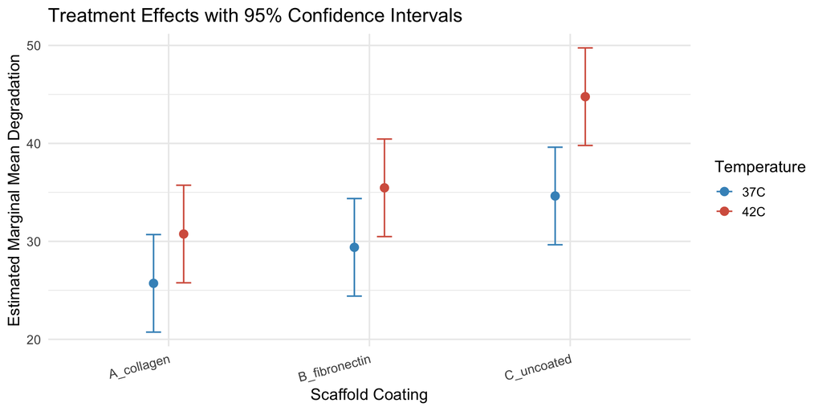

```r
emm_df <- as.data.frame(emm)

ggplot(emm_df, aes(x = treatment, y = emmean, color = temperature,
                    group = temperature)) +
  geom_point(size = 3, position = position_dodge(width = 0.3)) +
  geom_errorbar(aes(ymin = lower.CL, ymax = upper.CL),
                width = 0.15, position = position_dodge(width = 0.3)) +
  scale_color_manual(values = c("37C" = "#4393c3", "42C" = "#d6604d")) +
  labs(
    x = "Scaffold Coating",
    y = "Estimated Marginal Mean Degradation",
    color = "Temperature",
    title = "Treatment Effects with 95% Confidence Intervals"
  )
```

- Non-overlapping confidence intervals suggest significant differences
- The gap between temperatures for uncoated scaffolds is visibly larger than for collagen-coated — that’s the interaction
- These intervals are based on the mixed model, so they account for the clustering in the data
- This is the most informative plot for communicating your results

# Model Diagnostics

## Residual Diagnostics

- Output
- Code
- Explanation

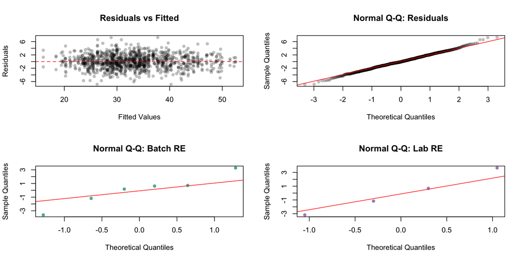

```r
par(mfrow = c(2, 2))

# Residuals vs fitted
plot(fitted(mod_full), resid(mod_full),
     xlab = "Fitted Values", ylab = "Residuals",
     main = "Residuals vs Fitted", pch = 16, col = "#00000040")
abline(h = 0, col = "red", lty = 2)

# QQ plot of residuals
qqnorm(resid(mod_full), main = "Normal Q-Q: Residuals", pch = 16, col = "#00000040")
qqline(resid(mod_full), col = "red")

# QQ plot of random effects - batch
re_batch <- ranef(mod_full)$batch[,1]
qqnorm(re_batch, main = "Normal Q-Q: Batch RE", pch = 16, col = "#5ab4ac")
qqline(re_batch, col = "red")

# QQ plot of random effects - lab
re_lab <- ranef(mod_full)$lab[,1]
qqnorm(re_lab, main = "Normal Q-Q: Lab RE", pch = 16, col = "#af8dc3")
qqline(re_lab, col = "red")

par(mfrow = c(1, 1))
```

- **Residuals vs Fitted:** check for homoscedasticity (constant spread) and no systematic pattern
- **QQ of Residuals:** check that residuals are approximately normally distributed
- **QQ of Random Effects:** the random effects should also be normally distributed — with few groups (6 batches, 4 labs), some deviation is expected
- These diagnostics are analogous to what you do for `lm()`, with the addition of checking random effect distributions

## Random Effects Estimates (BLUPs)

- Output
- Code
- Explanation

```
$`lab:technician`
```

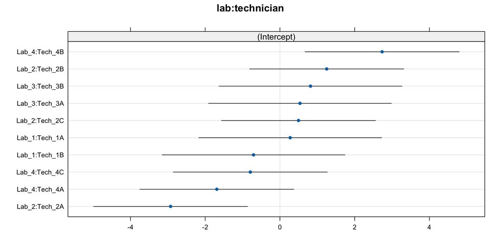

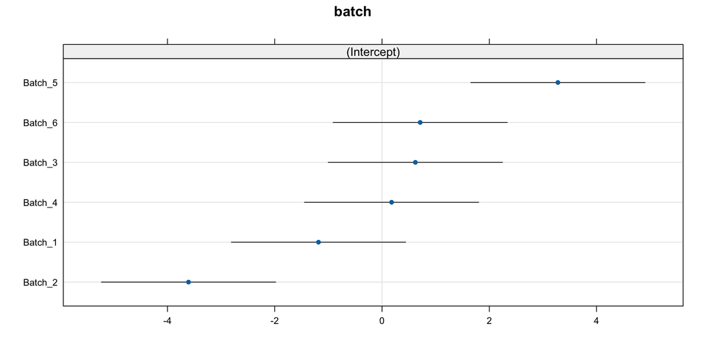

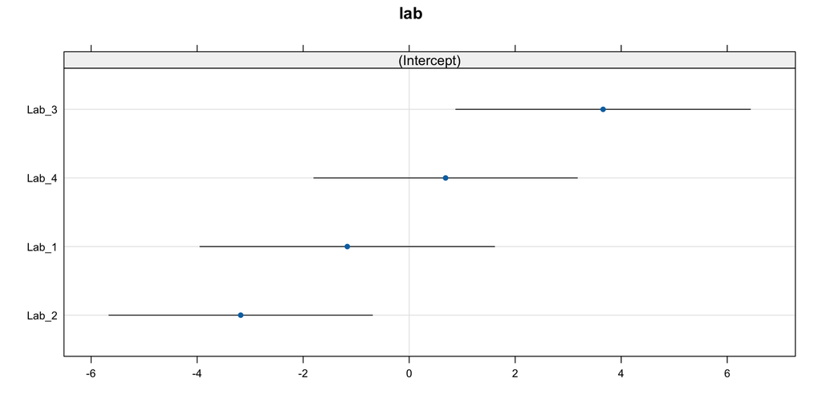

```r
# Caterpillar plots of random effects (BLUPs)
lattice::dotplot(ranef(mod_full, condVar = TRUE))
```

- `ranef()` extracts the **Best Linear Unbiased Predictors** (BLUPs) for each random effect level
- `condVar = TRUE` adds conditional variances, displayed as confidence intervals
- `dotplot()` from `lattice` (loaded by lme4) produces caterpillar plots
- Intervals that don’t overlap zero indicate groups that are notably above or below the grand mean
- These are **shrunken** estimates — pulled toward zero more when group sample sizes are small or group variance is small relative to residual variance

# Model Selection and Comparison

## REML vs. ML: Why It Matters for Model Comparison

When fitting mixed models, `lmer()` uses **REML** (Restricted Maximum Likelihood) by default. Understanding the difference between REML and ML is critical for model comparison:

**REML (default)**

- Adjusts for the number of fixed effects when estimating variance components
- Produces **unbiased** estimates of variance — analogous to dividing by $n-1$ instead of $n$
- The “restricted” likelihood is calculated after projecting out the fixed effects

**ML** (`REML = FALSE`)

- Estimates everything jointly — fixed effects and variance components together
- Variance estimates are slightly biased downward (like dividing by $n$)
- But the likelihood is a **true** likelihood that can be compared across models with different fixed effects

## When to Use Which

**The Comparison Rule**

Because REML projects out the fixed effects before computing the likelihood, two models with **different fixed effects** have projected away *different things*. Their REML likelihoods are on different scales and **cannot be meaningfully compared**.

- **Same fixed effects, different random** → compare with **REML** (default) — the projection is the same, so the likelihoods are comparable
- **Different fixed effects, same random** → compare with **ML** (`REML = FALSE`) — you need a true likelihood
- For final parameter estimates after model selection, refit the chosen model with **REML** for unbiased variance estimates

```r
# Comparing random structures (REML is fine — same fixed effects)
mod_a <- lmer(y ~ treatment * time + (1 | subject), data = d)
mod_b <- lmer(y ~ treatment * time + (1 + time | subject), data = d)
anova(mod_a, mod_b, refit = FALSE)  # keeps REML

# Comparing fixed structures (must use ML)
mod_c <- lmer(y ~ treatment * time + (1 | subject), data = d, REML = FALSE)
mod_d <- lmer(y ~ treatment + time + (1 | subject), data = d, REML = FALSE)
anova(mod_d, mod_c)  # ML likelihoods are comparable
```

## Comparing Models with Different Random Structures

- Output
- Code
- Explanation

```
               df      AIC
mod_batch_only  8 6008.269
mod_lab_only    8 5687.108
mod_both        9 5167.446
mod_full       10 4766.850
```

```r
mod_batch_only <- lmer(degradation ~ treatment * temperature + (1 | batch),
                       data = scaffold_data)
mod_lab_only   <- lmer(degradation ~ treatment * temperature + (1 | lab),
                       data = scaffold_data)
mod_both       <- lmer(degradation ~ treatment * temperature +
                         (1 | batch) + (1 | lab),
                       data = scaffold_data)

AIC(mod_batch_only, mod_lab_only, mod_both, mod_full)
```

- **AIC** (Akaike Information Criterion) balances fit and complexity — lower is better
- Comparing models with different random structures helps you determine which variance sources matter
- The full model includes all three random terms; simpler models omit some
- Large AIC differences (> 10) indicate strong evidence for the better model
- Use `refit = FALSE` with `anova()` for formal tests when models are nested in their random effects

## Model Selection: Fixed Effects

- Output
- Code
- Explanation

```
Data: scaffold_data
Models:
mod_noint_ml: degradation ~ treatment + temperature + (1 | batch) + (1 | lab) + (1 | lab:technician)
mod_full_ml: degradation ~ treatment * temperature + (1 | batch) + (1 | lab) + (1 | lab:technician)
             npar    AIC    BIC  logLik -2*log(L)  Chisq Df Pr(>Chisq)
mod_noint_ml    8 5020.7 5060.6 -2502.4    5004.7
mod_full_ml    10 4762.3 4812.2 -2371.2    4742.3 262.39  2  < 2.2e-16 ***
---
Signif. codes:  0 '***' 0.001 '**' 0.01 '*' 0.05 '.' 0.1 ' ' 1
```

```r
# Refit with ML (not REML) for comparing fixed effects
mod_full_ml  <- lmer(degradation ~ treatment * temperature +
                       (1 | batch) + (1 | lab) + (1 | lab:technician),
                     data = scaffold_data, REML = FALSE)
mod_noint_ml <- lmer(degradation ~ treatment + temperature +
                       (1 | batch) + (1 | lab) + (1 | lab:technician),
                     data = scaffold_data, REML = FALSE)

anova(mod_noint_ml, mod_full_ml)
```

- **Critical:** When comparing models with different **fixed** effects, you must use **ML** not REML (`REML = FALSE`)
- REML estimates depend on the fixed effects, so REML likelihoods are not comparable across models with different fixed structures
- When comparing models with different **random** effects but the same fixed effects, use REML (the default)
- This test asks: does the treatment × temperature interaction significantly improve the model?

# Summary and Key Takeaways

## lme4 Formula Syntax Quick Reference

| Random Effect | Syntax | Meaning |
| --- | --- | --- |
| Random intercept | `(1 \\| group)` | Each group has its own baseline |
| Random slope | `(1 + x \\| group)` | Each group has its own baseline AND slope for x |
| No correlation | `(1 + x \\|\\| group)` | Independent random intercept and slope |
| Nested | `(1 \\| A) + (1 \\| A:B)` | B nested within A |
| Crossed | `(1 \\| A) + (1 \\| B)` | A and B fully crossed |

**The Comparison Rule**

- Different **random** effects, same fixed → compare with **REML** (default)
- Different **fixed** effects, same random → compare with **ML** (`REML = FALSE`)

## Workflow for Mixed Model Analysis

1. **Visualize** your data — look for grouping structure and treatment patterns
2. **Start simple** — random intercept for the most obvious grouping variable
3. **Build up** — add random effects that match your experimental design
4. **Compare models** — use AIC/BIC and likelihood ratio tests
5. **Check diagnostics** — residual plots AND random effect normality
6. **Interpret fixed effects** — use `anova()` with Satterthwaite df from `lmerTest`
7. **Post-hoc comparisons** — use `emmeans()` for pairwise contrasts with proper error structure
8. **Report** — variance components, fixed effect tests, and estimated marginal means

## Common Convergence Issues

**When lmer() Won’t Converge**

- **Singular fit warning:** a variance component is estimated at or near zero — consider removing that random effect
- **Failed to converge:** try a different optimizer with `control = lmerControl(optimizer = "bobyqa")`
- **Random slope won’t converge:** remove the intercept-slope correlation with `||` or drop the random slope entirely
- **Too many random effects for the data:** you need enough groups (≥ 5–6) to estimate each variance component

When in doubt, start with the simplest defensible random structure and build up only if supported by the data and your design.

# Generalized Linear Models

## What is a GLM?

GLMs extend linear models to handle response variables that are not normally distributed. Use when standard linear model assumptions are violated:

- **Binary response** (e.g., survived/died) → logistic regression
- **Count response** (e.g., number of mutations) → Poisson regression

**Three components of every GLM:**

1. **Random component**: probability distribution of the response variable (e.g., binomial, Poisson)
2. **Systematic component**: linear combination of predictors ($\beta_0 + \beta_1 x_1 + \ldots$)
3. **Link function**: connects the random and systematic components

## GLM Families

| Family | Link Function | Use For | Example |
| --- | --- | --- | --- |
| Gaussian | identity | Continuous response | Standard linear model |
| Binomial | logit | Binary outcomes | Disease presence/absence |
| Poisson | log | Count data | Number of colonies |
| Gamma | inverse | Positive continuous | Reaction times |

## GLM Assumptions

- **Independence** of observations
- No overly **influential observations**
- **Linearity** between predictors and the link function (not between predictors and raw response)
- **Appropriate dispersion** (variance matches the assumed distribution)

## GLM in R

- Code
- Deviance

```r
# General syntax
glm(formula = y ~ x1 + x2,
    family = gaussian(link = "identity"),
    data = mydata)

# Binomial family for logistic regression
glm(y ~ x1 + x2, family = binomial, data = mydata)

# Poisson family for count data
glm(count ~ x1 + x2, family = poisson, data = mydata)
```

- **Deviance** measures model fit in GLMs (analogous to RSS in linear regression)
- **Null Deviance**: from model with only intercept
- **Residual Deviance**: from fitted model
- Large drop from null to residual deviance → better model fit

## GLM Diagnostics: Standard Approach

- Code
- Interpretation

```r
# Fit a GLM
model <- glm(y ~ x1 + x2, family = binomial, data = mydata)

# Residual deviance plot
plot(predict(model, type = "link"), residuals(model, type = "deviance"),
     xlab = "Linear Predictor", ylab = "Deviance Residuals",
     main = "GLM Deviance Residuals")
abline(h = 0, col = "red", lty = 2)

# Influential observations
plot(cooks.distance(model), type = "h",
     main = "Cook's Distance", ylab = "Cook's Distance")
```

- **Deviance residuals vs. linear predictor**: Should show no systematic pattern — look for fans, curves, or heteroscedasticity
- **Cook’s Distance**: Identifies influential observations — points with Cook’s D > 0.5 warrant investigation
- Standard residual plots work for Gaussian GLMs, but are harder to interpret for binomial and Poisson families because the expected residual pattern depends on the fitted values

## GLM Diagnostics: DHARMa (Simulation-Based)

The **DHARMa** package solves the residual interpretation problem for non-Gaussian GLMs by simulating residuals that should always be uniformly distributed if the model is correct.

- Output
- Code
- Interpretation

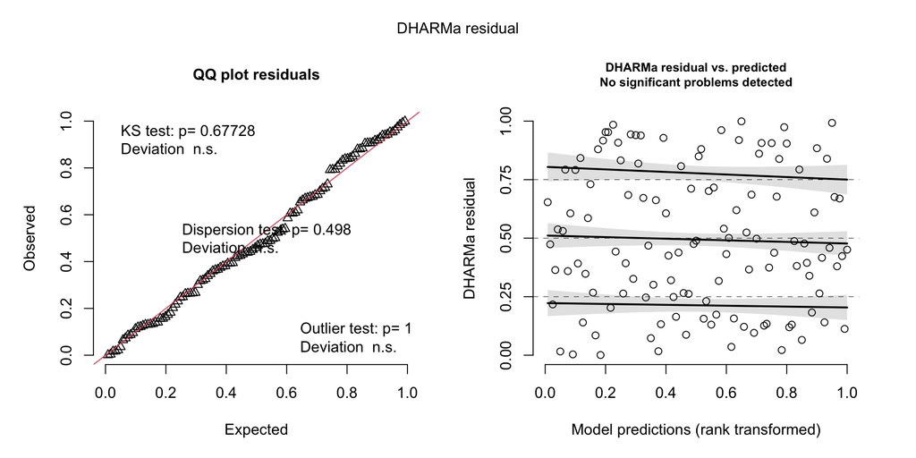

```r
library(DHARMa)

# Simulate residuals from the fitted Poisson model
sim_res <- simulateResiduals(fittedModel = pois_model, n = 1000)

# The default plot shows QQ + residual vs predicted
plot(sim_res)

# Additional targeted tests
testDispersion(sim_res)    # overdispersion?
testZeroInflation(sim_res) # excess zeros?
testOutliers(sim_res)      # outlier detection
```

- **Left panel (QQ plot)**: DHARMa transforms residuals to be uniform under the correct model. Points should follow the diagonal — deviations indicate misspecification. The KS test provides a formal check.
- **Right panel (Residual vs. predicted)**: Quantile lines should be horizontal at 0.25, 0.50, and 0.75. A fan or curve indicates heteroscedasticity or wrong link function.
- **Dispersion test**: If the dispersion statistic is significantly > 1, your Poisson model is overdispersed — switch to quasi-Poisson or negative binomial.
- DHARMa works for any `glm`, `glmer`, `glmmTMB`, or `gam` model — making it the universal diagnostic tool for GLMs.

# BREAK

# Logistic Regression

## What is Logistic Regression?

- Classification algorithm for **binary outcomes** (0/1, yes/no, survived/died)
- Uses the **logit** link function to map outputs between 0 and 1
- Equation
- LaTeX

$$P(y = 1 \mid x) = \frac{1}{1 + e^{-(\beta_0 + \beta_1 x)}}$$

```
P(y = 1 \mid x) = \frac{1}{1 + e^{-(\beta_0 + \beta_1 x)}}
```

## The Logistic Function

- Output
- Code

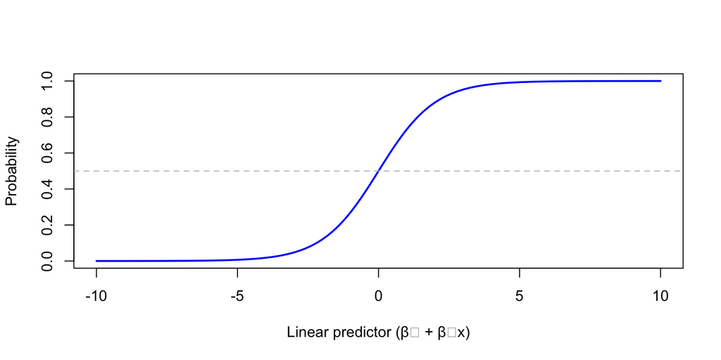

```r
curve(1 / (1 + exp(-x)), from = -10, to = 10, col = "blue", lwd = 2,
      ylab = "Probability", xlab = "Linear predictor (β₀ + β₁x)")
abline(h = 0.5, lty = 2, col = "gray")
```

## Odds and Log-Odds

- Equations
- LaTeX

**Odds:**
$$\frac{P}{1 - P}$$

**Log-odds (logit):**
$$\log\left(\frac{P}{1 - P}\right)$$

**Model equation:**
$$\log\left(\frac{P(y=1)}{1 - P(y=1)}\right) = \beta_0 + \beta_1 x$$

```
\text{Odds} = \frac{P}{1 - P}

\text{Log-odds (logit)} = \log\left(\frac{P}{1 - P}\right)

\text{Model:} \log\left(\frac{P(y=1)}{1 - P(y=1)}\right) = \beta_0 + \beta_1 x
```

## Logistic Regression in R

- Output
- Code

```
Call:
glm(formula = am ~ mpg, family = binomial, data = mtcars)

Coefficients:
            Estimate Std. Error z value Pr(>|z|)
(Intercept)  -6.6035     2.3514  -2.808  0.00498 **
mpg           0.3070     0.1148   2.673  0.00751 **
---
Signif. codes:  0 '***' 0.001 '**' 0.01 '*' 0.05 '.' 0.1 ' ' 1

(Dispersion parameter for binomial family taken to be 1)

    Null deviance: 43.230  on 31  degrees of freedom
Residual deviance: 29.675  on 30  degrees of freedom
AIC: 33.675

Number of Fisher Scoring iterations: 5
```

```r
data(mtcars)
mtcars$am <- factor(mtcars$am)
model <- glm(am ~ mpg, data = mtcars, family = binomial)
summary(model)
```

## Interpreting Coefficients

Coefficients are in **log-odds** — exponentiate to get odds ratios:

- Output
- Code

```
(Intercept)         mpg
0.001355579 1.359379288
```

```r
exp(coef(model))
```

$\exp(\beta_1)$ is the **multiplicative change in odds** for a 1-unit increase in the predictor. For example, if $\exp(\beta_1) = 1.35$, a one-unit increase in mpg multiplies the odds of manual transmission by 1.35 (a 35% increase).

**Interpreting Odds Ratios**

- OR = 1 → no effect
- OR > 1 → higher odds of the outcome
- OR < 1 → lower odds of the outcome
- An OR of 2.0 means the odds double; an OR of 0.5 means the odds halve

## Bioengineering Example: Predicting Implant Failure

- Output
- Code
- Interpretation

```
=== Model Summary ===
```

```
Call:
glm(formula = failure ~ surface_roughness + coating_thickness +
    load_cycles, family = binomial, data = implant_data)

Coefficients:
                    Estimate Std. Error z value Pr(>|z|)
(Intercept)       -2.211e+00  1.193e+00  -1.854   0.0637 .
surface_roughness  1.583e+00  4.049e-01   3.909 9.25e-05 ***
coating_thickness -2.852e-02  1.428e-02  -1.997   0.0458 *
load_cycles        1.644e-07  1.716e-07   0.958   0.3381
---
Signif. codes:  0 '***' 0.001 '**' 0.01 '*' 0.05 '.' 0.1 ' ' 1

(Dispersion parameter for binomial family taken to be 1)

    Null deviance: 201.06  on 149  degrees of freedom
Residual deviance: 177.08  on 146  degrees of freedom
AIC: 185.08

Number of Fisher Scoring iterations: 3
```

```
=== Odds Ratios with 95% CI ===
```

```
                     OR 2.5 % 97.5 %
(Intercept)       0.110 0.010  1.098
surface_roughness 4.869 2.279 11.247
coating_thickness 0.972 0.944  0.999
load_cycles       1.000 1.000  1.000
```

```r
# Simulated implant failure data
set.seed(2026)
n <- 150
implant_data <- data.frame(
  surface_roughness = rnorm(n, 1.5, 0.5),     # micrometers
  coating_thickness = rnorm(n, 50, 15),         # nm
  load_cycles       = rnorm(n, 5e6, 1e6)       # cycles
)
implant_data$failure <- rbinom(n, 1,
  plogis(-3 + 1.5 * implant_data$surface_roughness -
         0.02 * implant_data$coating_thickness +
         0.0000003 * implant_data$load_cycles))

# Fit logistic regression
implant_glm <- glm(failure ~ surface_roughness + coating_thickness + load_cycles,
                    family = binomial, data = implant_data)
summary(implant_glm)

# Odds ratios with confidence intervals
exp(cbind(OR = coef(implant_glm), confint(implant_glm)))
```

- **Surface roughness** (OR > 1): Rougher implant surfaces increase odds of failure — each 1 μm increase in roughness substantially raises failure risk
- **Coating thickness** (OR < 1): Thicker protective coatings reduce failure odds — the coating acts as a protective barrier
- **Load cycles** (OR ≈ 1): The very small OR change per single cycle masks the effect — rescale to millions of cycles for practical interpretation
- The deviance drop from null to residual (and low AIC) indicate the predictors collectively explain meaningful variation in failure rates
- Always report odds ratios with 95% CIs, not just p-values — the CI width conveys the precision of your estimate

## ROC Curve and AUC

- Output
- Code

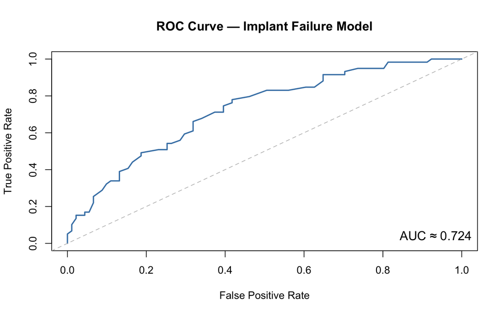

```r
# Using pROC package for ROC curves
library(pROC)

pred_probs <- predict(implant_glm, type = "response")
roc_obj <- roc(implant_data$failure, pred_probs)

# Plot ROC curve
plot(roc_obj, col = "steelblue", lwd = 2,
     main = "ROC Curve — Implant Failure Model")
cat("AUC:", auc(roc_obj))

# Optimal threshold (Youden's J statistic)
coords(roc_obj, "best", ret = c("threshold", "sensitivity", "specificity"))

# Confusion matrix at optimal threshold
optimal_thresh <- coords(roc_obj, "best")$threshold
pred_class <- ifelse(pred_probs >= optimal_thresh, 1, 0)
table(Predicted = pred_class, Actual = implant_data$failure)
```

## Model Evaluation Metrics

| Metric | Formula |
| --- | --- |
| **Accuracy** | $(TP + TN) / (TP + TN + FP + FN)$ |
| **Precision** | $TP / (TP + FP)$ |
| **Recall** | $TP / (TP + FN)$ |
| **F1 Score** | $2 \cdot \frac{Precision \cdot Recall}{Precision + Recall}$ |

## Confusion Matrix

|  | Predicted Positive | Predicted Negative |
| --- | --- | --- |
| **Actual Positive** | True Positive (TP) | False Negative (FN) |
| **Actual Negative** | False Positive (FP) | True Negative (TN) |

# Poisson Regression

## What is Poisson Regression?

Models **count data** where the response variable represents the number of times an event occurs:

- Equation
- LaTeX

$$\log(\lambda_i) = \beta_0 + \beta_1 x_{i1} + \ldots + \beta_p x_{ip}$$

```
\log(\lambda_i) = \beta_0 + \beta_1 x_{i1} + \ldots + \beta_p x_{ip}
```

Assumes Poisson distribution: **Mean = Variance = λ**

## Poisson Regression in R

- Code
- Overdispersion Solutions

```r
# Fit Poisson model
model <- glm(count ~ x1 + x2, family = poisson, data = mydata)

# Check for overdispersion
dispersion <- sum(residuals(model, type = "pearson")^2) / model$df.residual
cat("Dispersion parameter:", dispersion)
# If >> 1, overdispersion is present
```

When variance > mean (overdispersion):

- **Quasi-Poisson**: Adjusts standard errors but keeps same coefficients
- **Negative Binomial**: Adds a parameter for extra-Poisson variation

```r
# Quasi-Poisson
model_qp <- glm(count ~ x1 + x2, family = quasipoisson, data = mydata)

# Negative Binomial
library(MASS)
model_nb <- glm.nb(count ~ x1 + x2, data = mydata)
```

## Poisson Worked Example: Colony Counts

- Output
- Code

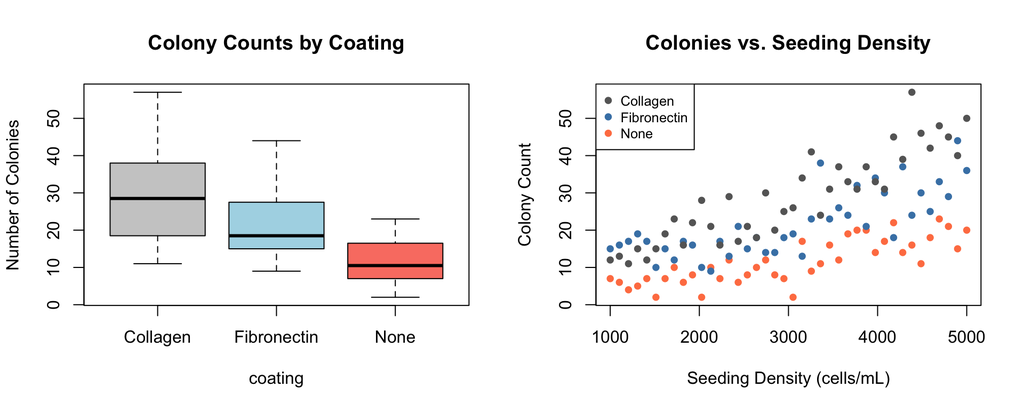

```r
# Bioengineering Poisson regression: bacterial colony counts
# on tissue culture plates with different surface coatings
set.seed(2026)
n <- 120
colony_data <- data.frame(
  coating = factor(rep(c("None", "Fibronectin", "Collagen"), each = 40)),
  seeding = rep(seq(1000, 5000, length.out = 40), 3)
)
colony_data$colonies <- rpois(n, exp(
  1.5 + 0.6 * (colony_data$coating == "Fibronectin") +
  0.9 * (colony_data$coating == "Collagen") +
  0.0003 * colony_data$seeding))

# Fit Poisson GLM
pois_model <- glm(colonies ~ coating + seeding, family = poisson,
                   data = colony_data)
summary(pois_model)

# Check overdispersion
disp <- sum(residuals(pois_model, type = "pearson")^2) / pois_model$df.residual
cat("Dispersion:", round(disp, 2), "\n")

# If overdispersed, compare models
if (disp > 1.5) {
  qp_model <- glm(colonies ~ coating + seeding, family = quasipoisson,
                   data = colony_data)
  nb_model <- MASS::glm.nb(colonies ~ coating + seeding, data = colony_data)

  cat("Poisson AIC:", AIC(pois_model), "\n")
  cat("Neg Binom AIC:", AIC(nb_model), "\n")
}

# Exponentiate for rate ratios
exp(coef(pois_model))
exp(confint(pois_model))
```

## Poisson vs. Quasi-Poisson vs. Negative Binomial

| Model | Dispersion | Use When | R Function |
| --- | --- | --- | --- |
| **Poisson** | φ ≈ 1 | Variance ≈ mean | `glm(..., family = poisson)` |
| **Quasi-Poisson** | φ > 1 | Mild overdispersion | `glm(..., family = quasipoisson)` |
| **Neg. Binomial** | φ >> 1 | Severe overdispersion | `MASS::glm.nb()` |

**Tip**

Always check overdispersion first. If the dispersion parameter is close to 1, standard Poisson is fine. If it exceeds ~1.5, consider quasi-Poisson (same coefficients, wider CIs) or negative binomial (different model entirely).

# Regularization Methods

## Why Regularization?

Standard linear regression struggles when:

- **Multicollinearity**: Correlated predictors lead to unstable coefficient estimates
- **High dimensionality**: More predictors than observations (p > n)
- **Overfitting**: Model fits training data too closely, poor generalization

**Solution**: Add a penalty term that **shrinks coefficients toward zero**, trading a small amount of bias for a large reduction in variance.

## Ridge Regression (L2 Penalty)

- Equation
- LaTeX
- Properties
- When to Interpret

$$\hat{\beta}_{ridge} = \arg\min_{\beta} \left[ \sum_{i=1}^{n} (y_i - x_i^T\beta)^2 + \lambda \sum_{j=1}^{p} \beta_j^2 \right]$$

```
\hat{\beta}_{ridge} = \arg\min_{\beta} \left[ \sum_{i=1}^{n} (y_i - x_i^T\beta)^2 + \lambda \sum_{j=1}^{p} \beta_j^2 \right]
```

- Penalty: $\sum \beta_j^2$ (L2 norm — sum of squared coefficients)
- Shrinks coefficients toward zero but **never exactly zero**
- Handles multicollinearity well
- Closed-form solution: $\hat{\beta}_{ridge} = (X^TX + \lambda I)^{-1}X^Ty$
- As λ → 0: approaches OLS; as λ → ∞: coefficients → 0
- Ridge is ideal when you have correlated biomaterial properties (e.g., porosity and pore size are correlated but both matter)
- All predictors stay in the model — useful when you believe all measured properties contribute, even if slightly
- The **λ** parameter controls how much you distrust OLS: higher λ = more shrinkage = more bias but less variance
- Select λ via cross-validation: `cv.glmnet()` finds the λ that minimizes prediction error on held-out data

## Lasso Regression (L1 Penalty)

- Equation
- LaTeX
- Properties
- When to Interpret

$$\hat{\beta}_{lasso} = \arg\min_{\beta} \left[ \sum_{i=1}^{n} (y_i - x_i^T\beta)^2 + \lambda \sum_{j=1}^{p} |\beta_j| \right]$$

```
\hat{\beta}_{lasso} = \arg\min_{\beta} \left[ \sum_{i=1}^{n} (y_i - x_i^T\beta)^2 + \lambda \sum_{j=1}^{p} |\beta_j| \right]
```

- Penalty: $\sum |\beta_j|$ (L1 norm — sum of absolute values)
- Can set coefficients **exactly to zero** → performs variable selection
- No closed-form solution (requires optimization)
- Produces **sparse models** — useful when you believe many predictors are irrelevant
- Lasso is ideal when you suspect only a subset of your measured properties actually matter (common in high-throughput screening)
- Example: You measure 50 biomaterial surface properties but only 5 truly predict cell adhesion — Lasso finds those 5
- **Caution**: Among a group of correlated predictors, Lasso arbitrarily selects one and zeroes out the others. If you need all correlated predictors, use Elastic Net.
- The selected variables form a sparse, interpretable model — report the non-zero coefficients as the “important” predictors

## Elastic Net

Combines Ridge and Lasso penalties:

- Equation
- LaTeX

$$\hat{\beta}_{elastic} = \arg\min_{\beta} \left[ RSS + \lambda \left( \alpha \sum |\beta_j| + (1-\alpha) \sum \beta_j^2 \right) \right]$$

```
\hat{\beta}_{elastic} = \arg\min_{\beta} \left[ RSS + \lambda \left( \alpha \sum |\beta_j| + (1-\alpha) \sum \beta_j^2 \right) \right]
```

- α = 0: pure Ridge; α = 1: pure Lasso
- Variable selection like Lasso + handles correlated features like Ridge
- Often the best default choice

**Practical Guidance**

In bioengineering high-dimensional data (proteomics, material characterization, gene expression), start with **Elastic Net (α = 0.5)** as a safe default. If you need a minimal predictor set, increase α toward 1 (Lasso). If prediction accuracy matters more than variable selection, decrease α toward 0 (Ridge). Use `cv.glmnet()` to optimize both α and λ simultaneously.

## Regularization in R

- Code
- When to Use

```r
library(glmnet)

# Ridge regression (alpha = 0)
ridge_cv <- cv.glmnet(X_train, y_train, alpha = 0, nfolds = 10)
ridge_model <- glmnet(X_train, y_train, alpha = 0, lambda = ridge_cv$lambda.min)

# Lasso regression (alpha = 1)
lasso_cv <- cv.glmnet(X_train, y_train, alpha = 1, nfolds = 10)
lasso_model <- glmnet(X_train, y_train, alpha = 1, lambda = lasso_cv$lambda.min)

# Elastic net (alpha between 0 and 1)
elastic_cv <- cv.glmnet(X_train, y_train, alpha = 0.5, nfolds = 10)
```

| Method | Use When |
| --- | --- |
| **Ridge** | Many predictors, most relevant; multicollinearity |
| **Lasso** | Feature selection important; many irrelevant predictors |
| **Elastic Net** | Groups of correlated predictors; best of both worlds |

## Geometric Interpretation

- **Ridge** constraint region: circle/sphere (smooth boundary) → coefficients shrink continuously
- **Lasso** constraint region: diamond/polytope (corners at axes) → coefficients can be exactly zero at the corners
- The intersection of the elliptical RSS contours with the constraint region determines the solution

## Visualizing Regularization Paths

- Code
- Interpretation

```r
# Fit models across range of lambda values
ridge_path <- glmnet(X_train, y_train, alpha = 0)
lasso_path <- glmnet(X_train, y_train, alpha = 1)

# Plot coefficient paths
par(mfrow = c(1, 2))
plot(ridge_path, xvar = "lambda", main = "Ridge Regression Path")
plot(lasso_path, xvar = "lambda", main = "Lasso Regression Path")
```

- Each line represents one coefficient as λ changes
- Ridge: all coefficients shrink together toward zero
- Lasso: coefficients drop to exactly zero at different λ values
- Cross-validation selects the optimal λ

## Regularization Worked Example: Biomaterial Properties

- Output
- Visualization
- Code
- Interpretation

```
=== Lasso Selected Coefficients (non-zero) ===
```

```
13 x 1 sparse Matrix of class "dgCMatrix"
            lambda.min
(Intercept)      0.018
property_1       2.962
property_2       0.096
property_3      -1.699
property_4      -0.131
property_5      -0.557
property_6      -0.356
property_7       1.217
property_8       0.491
property_12      0.539
property_13      0.018
property_14      0.361
property_15      0.238
```

```
=== Test Set RMSE ===
```

```
Lasso: 2.195
```

```
Ridge: 2.238
```

```
OLS:   2.201
```

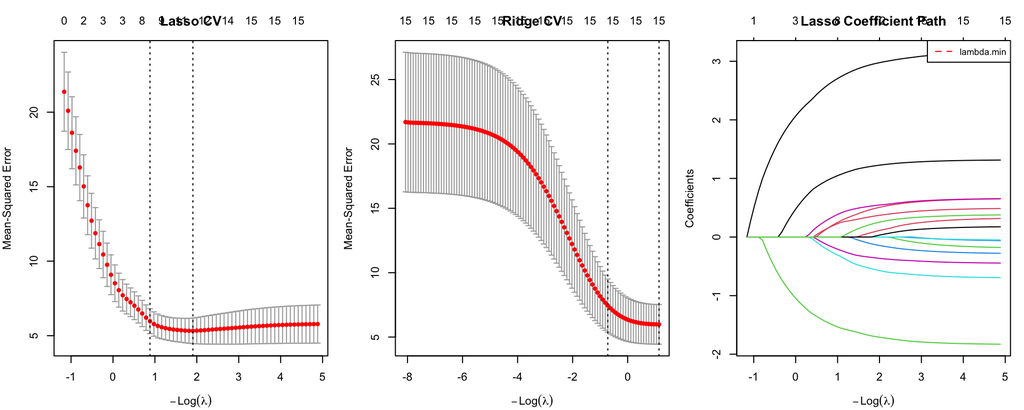

```r
library(glmnet)

# Simulated: 15 material properties, only 4 truly matter
set.seed(42)
n <- 100; p <- 15
X <- matrix(rnorm(n * p), n, p)
colnames(X) <- paste0("property_", 1:p)
y <- 3 * X[,1] - 2 * X[,3] + 1.5 * X[,7] + 0.8 * X[,12] + rnorm(n, 0, 2)

# Train/test split
train_idx <- sample(n, 0.7 * n)
X_train <- X[train_idx, ]; y_train <- y[train_idx]
X_test  <- X[-train_idx, ]; y_test  <- y[-train_idx]

# Cross-validated Lasso and Ridge
lasso_cv <- cv.glmnet(X_train, y_train, alpha = 1, nfolds = 10)
ridge_cv <- cv.glmnet(X_train, y_train, alpha = 0, nfolds = 10)

# Extract Lasso coefficients — which properties survived?
coef(lasso_cv, s = "lambda.min")
```

# LOESS: Exploratory Smoothing

## When Linear Isn’t Enough

Before fitting formal non-linear models, you often need to **explore** whether a non-linear relationship exists. LOESS (Locally Estimated Scatterplot Smoothing) is the go-to tool for this — it’s built into `ggplot2` as `geom_smooth()` and requires no assumptions about functional form.

LOESS answers the question: “Is there a trend in these data, and what does it look like?” It’s exploratory, not inferential — use it to guide model selection, not to report final results.